# Climate Change is Fake News

## KWIC

This is for Health related terms.

```r
tok.hea <- kwic(tok.compound, c("malaria", "diarrhoea", "infection", "disease", "sars", "measles", "pneumonia", "epidemic", "pandemic", "public_health", "health_care", "epidemiology", "healthcare", "health", "mortality", "morbidity", "nutrition", "illness", "infectious", "ncd", "non-communicable_disease", "noncommunicable_disease", "communicable_disease", "air_pollution", "nutrition", "malnutrition", "mental_disorder", "stunting"), window = 50, valuetype = "regex")
```

Climate change related terms.

```r
tok.cc <- kwic(tok.compound, c("climate_change", "global_warming", "green_house", "temperature", "extreme_weather", "global_environmental_change", "climate_variability", "greenhouse", "low_carbon", "ghge", "renewable_energy", "carbon_emission", "co2_emission", "climate_pollutant"), window = 50, valuetype = "regex")
```

Here we’re getting the intersection of health and climate. We take tokens associated with health terms (50 tokens before and after each health related key term) and within this set of tokens we perform KWIC for climate change selected terms. We limit the window here to 10 in order to get at this intersection.

```r
tok.x <- kwic(as.tokens(tok.hea), c("climate_change", "global_warming", "green_house", "temperature", "extreme_weather", "global_environmental_change", "climate_variability", "greenhouse", "low_carbon", "ghge", "renewable_energy", "carbon_emission", "co2_emission", "climate_pollutant"), window = 10, valuetype = "regex")
```

Saving the results for browsing.

```r
readr::write_csv(tok.hea, "health_kwic.csv")
readr::write_csv(tok.cc, "cc_kwic.csv")
readr::write_csv(tok.x, "intersection_kwic.csv")
```

```r
data_x <- as.data.frame(dfm(as.tokens(tok.x), dictionary =mydict))
temp <- as.data.frame(str_split(row.names(data_x), "_", simplify = TRUE))
temp$V2 <- as.numeric(as.character(temp$V2))
dataframe <- as.data.frame(table(temp$V1, temp$V2))
sum <- summarise(group_by(dataframe, Var2), count = sum(Freq))
```

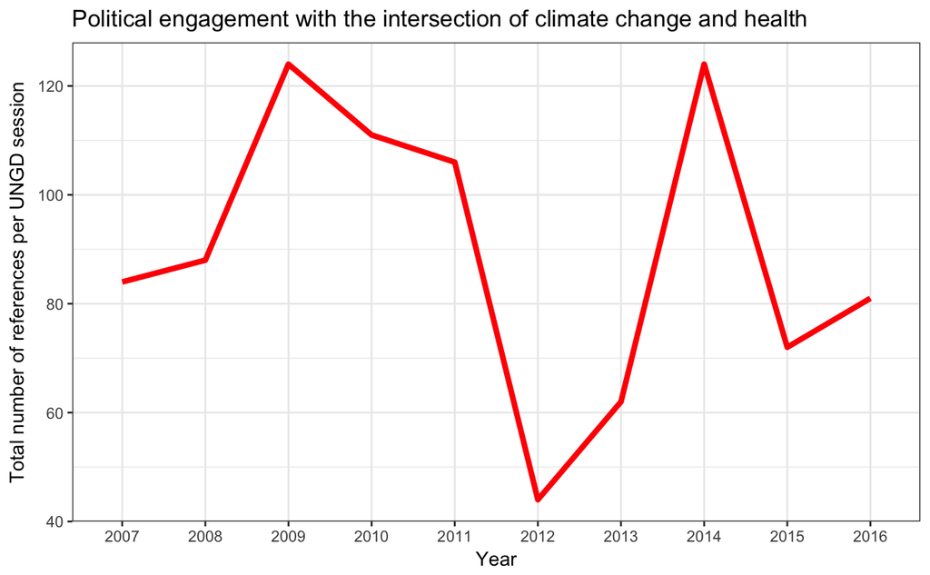

```r
ggplot(sum, aes(x=Var2, y=count, group = 1)) +
  geom_line(colour="red", size=1.5) +
  theme_bw() +
  ggtitle("Political engagement with the intersection of climate change and health") +
  ylab("Total number of references per UNGD session") + xlab("Year")
  ggsave("intersection.pdf")
```

```r
dfm.intersection <- dfm(as.tokens(tok.x), remove = stopwords("SMART"))
dfm.health <- dfm(as.tokens(tok.hea), remove = stopwords("SMART"))
dfm.climate <- dfm(as.tokens(tok.cc), remove = stopwords("SMART"))
```

```r
pdf("wordcloud_intersection.pdf")
textplot_wordcloud(dfm.intersection, max.words=200, scale=c(2,1), random.order=FALSE)
dev.off()
```

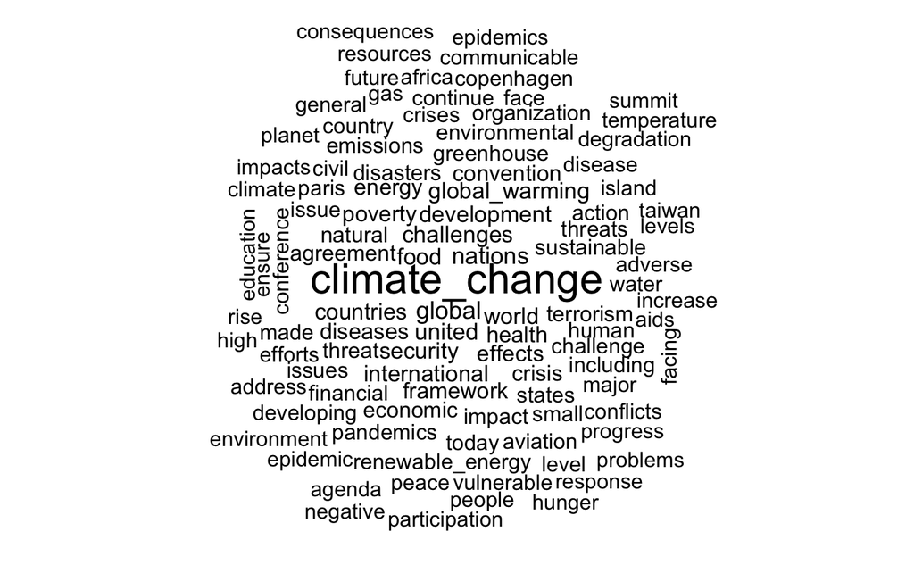

```r
textplot_wordcloud(dfm.intersection, max.words=100, scale=c(2,1), random.order=FALSE)
```

```r
pdf("wordcloud_health.pdf")
textplot_wordcloud(dfm.health, max.words=200, scale=c(2,1), random.order=FALSE)
dev.off()
```

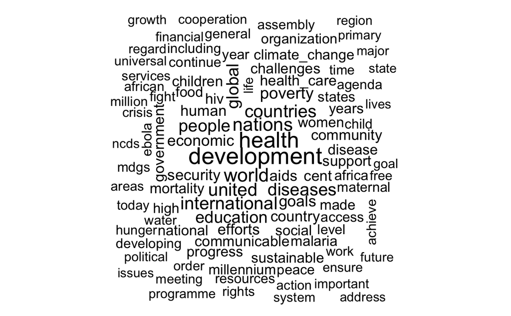

```r
textplot_wordcloud(dfm.health, max.words=100, scale=c(2,1), random.order=FALSE)
```

```r
pdf("wordcloud_climate.pdf")
textplot_wordcloud(dfm.climate, max.words=200, scale=c(2,1), random.order=FALSE)
dev.off()
```

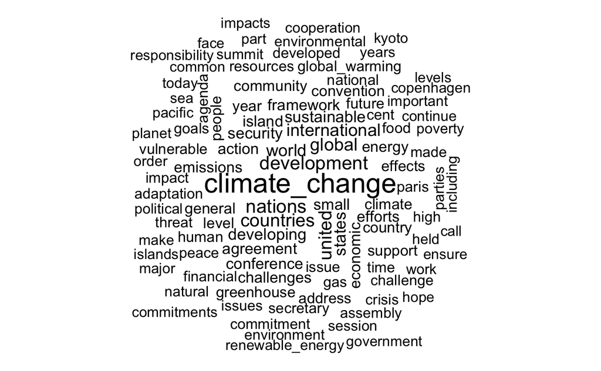

```r
textplot_wordcloud(dfm.climate, max.words=100, scale=c(2,1), random.order=FALSE)
```

Using UN M49 Standard (Standard country or area codes for statistical use (M49)) we create regional and sub-regional groupings of countries. [https://unstats.un.org/unsd/methodology/m49/]

```r
regions <- read.csv("UNSD - Methodology.csv")
regions$ISO.alpha3.Code <- as.character(regions$ISO.alpha3.Code)
regions$Region.Name <- as.character(regions$Region.Name)
regions$Sub.region.Name <- as.character(regions$Sub.region.Name)
```

```r
temp$V1 <- str_replace(temp$V1, "YUG", "SRB")
regional_data <- inner_join(temp, regions, by = c("V1" = "ISO.alpha3.Code"))
reg_dataframe <- as.data.frame(table(regional_data$Region.Name, regional_data$V2))
reg_sum <- summarise(group_by(reg_dataframe, Var1, Var2), count = sum(Freq))
reg_sum$Var2 <- as.numeric(as.character(reg_sum$Var2))
```

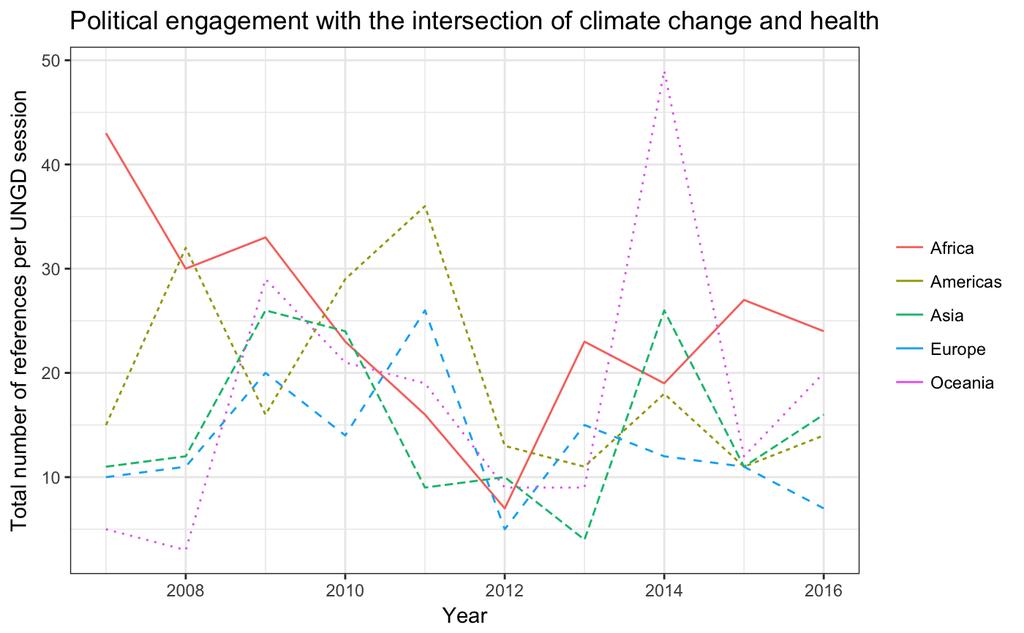

```r
ggplot(reg_sum, aes(x=Var2, y=count, group=Var1, colour = Var1, linetype = Var1)) +
  geom_line() +
  guides(colour=guide_legend(title=NULL), linetype = FALSE) +
  theme_bw() +
  ggtitle("Political engagement with the intersection of climate change and health") +
  ylab("Total number of references per UNGD session") + xlab("Year")
  ggsave("intersection_by_region.pdf")
```

```r
tok.tot <- tokens_lookup(tok.compound, mydict, valuetype = "regex", exclusive = TRUE)
data.tot <- as.data.frame(dfm(tok.tot))
temp.tot <- as.data.frame(str_split(row.names(data.tot), "_", simplify = TRUE))
temp.tot$V2 <- as.numeric(as.character(temp.tot$V2))
temp.tot$V1 <- as.character(temp.tot$V1)
data.complete <- cbind(temp.tot, data.tot)
sum.tot <- summarise(group_by(data.complete, V2),
                     countHEA = sum(health), countCC = sum(climate),
                     meanHEA = mean(health), meanCC = mean(climate))
```

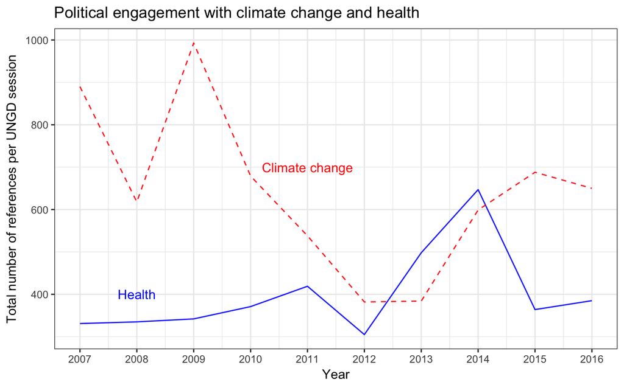

```r
ggplot(data = sum.tot, aes(x=V2))+
  theme_bw() +
  ggtitle("Political engagement with climate change and health") +
  ylab("Total number of references per UNGD session") + xlab("Year") +
  geom_line(aes(y= countHEA), colour = "blue", alpha = 0.9) +
  geom_line(aes(y= countCC), colour = "red", alpha = 0.9, linetype="dashed") +
#    geom_point(aes(y= mean_health), colour = "blue", alpha = 0.9, shape = 2) +
#  geom_point(aes(y = mean_climate), colour = "red", alpha = 0.9, shape = 21) +
  scale_x_continuous(breaks = seq(2007,2016,1)) +
 annotate("text", x = 2011, y = 700, label = "Climate change", colour = "red")+
  annotate("text", x = 2008, y = 400, label = "Health", colour = "blue")
ggsave("totals.pdf")
```

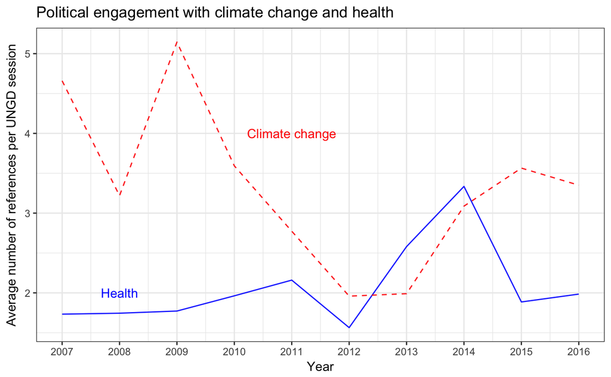

```r
ggplot(data = sum.tot, aes(x=V2))+
  theme_bw() +
  ggtitle("Political engagement with climate change and health") +
  ylab("Average number of references per UNGD session") + xlab("Year") +
  geom_line(aes(y= meanHEA), colour = "blue", alpha = 0.9) +
  geom_line(aes(y= meanCC), colour = "red", alpha = 0.9, linetype="dashed") +
#    geom_point(aes(y= mean_health), colour = "blue", alpha = 0.9, shape = 2) +
#  geom_point(aes(y = mean_climate), colour = "red", alpha = 0.9, shape = 21) +
  scale_x_continuous(breaks = seq(2007,2016,1)) +
 annotate("text", x = 2011, y = 4, label = "Climate change", colour = "red")+
  annotate("text", x = 2008, y = 2, label = "Health", colour = "blue")
ggsave("averages.pdf")
```

```r
data.complete$V1 <- str_replace(data.complete$V1, "YUG", "SRB")
regional_data_tot <- left_join(data.complete, regions, by = c("V1" = "ISO.alpha3.Code"))
#speeches by EU are not matched onto ISO codes
regional_data_tot$Region.Name[is.na(regional_data_tot$Region.Name)] <- "Europe"
regional_data_tot$Region.Name[is.na(regional_data_tot$Region.Name)] <- "Europe"
region_sum_tot <- summarise(group_by(regional_data_tot, Region.Name, V2),
                         countHEA = sum(health), countCC = sum(climate),
                         meanHEA = mean(health), meanCC = mean(climate))
```

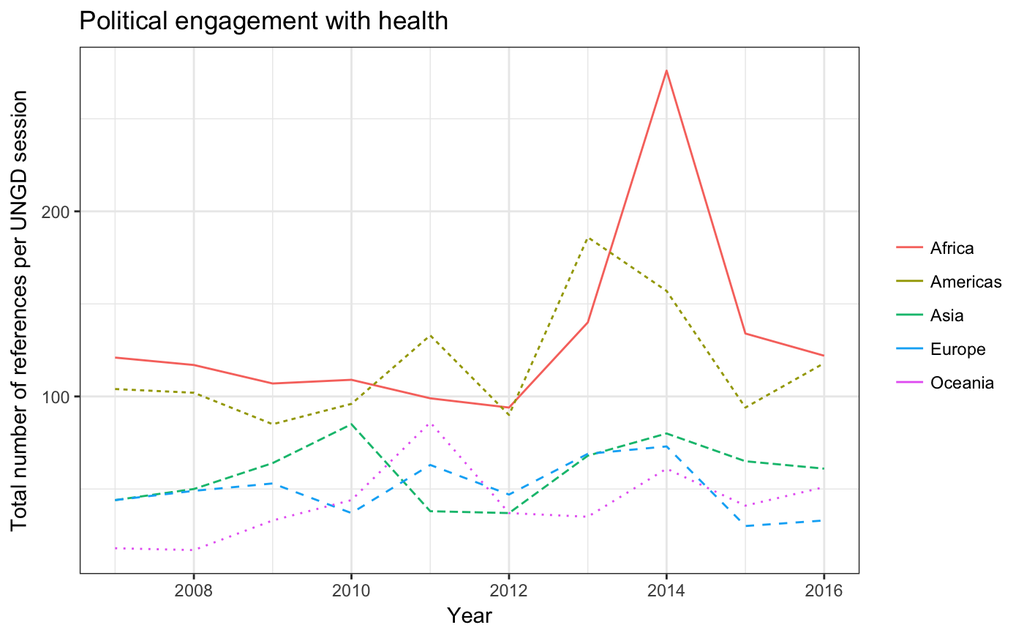

```r
ggplot(region_sum_tot, aes(x=V2, y=countHEA, group=Region.Name,
                           colour = Region.Name, linetype = Region.Name)) +
  geom_line() +
  guides(colour=guide_legend(title=NULL), linetype = FALSE) +
  theme_bw() +
  ggtitle("Political engagement with health") +
  ylab("Total number of references per UNGD session") + xlab("Year")
  ggsave("total_health_by_region.pdf")
```

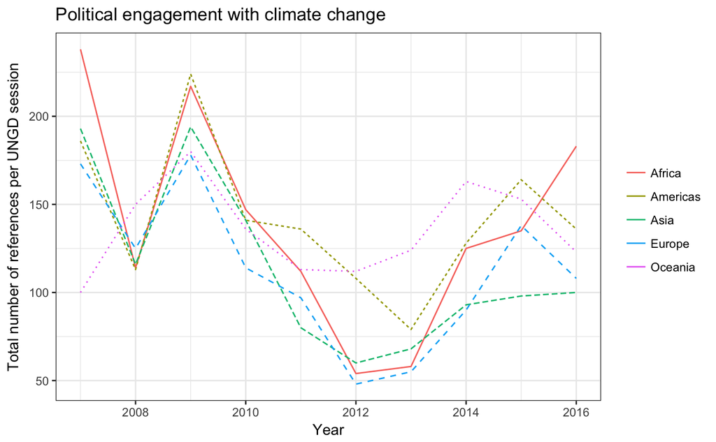

```r
ggplot(region_sum_tot, aes(x=V2, y=countCC, group=Region.Name,
                           colour = Region.Name, linetype = Region.Name)) +
  geom_line() +
  guides(colour=guide_legend(title=NULL), linetype = FALSE) +
  theme_bw() +
  ggtitle("Political engagement with climate change") +
  ylab("Total number of references per UNGD session") + xlab("Year")
  ggsave("total_climate_by_region.pdf")
```

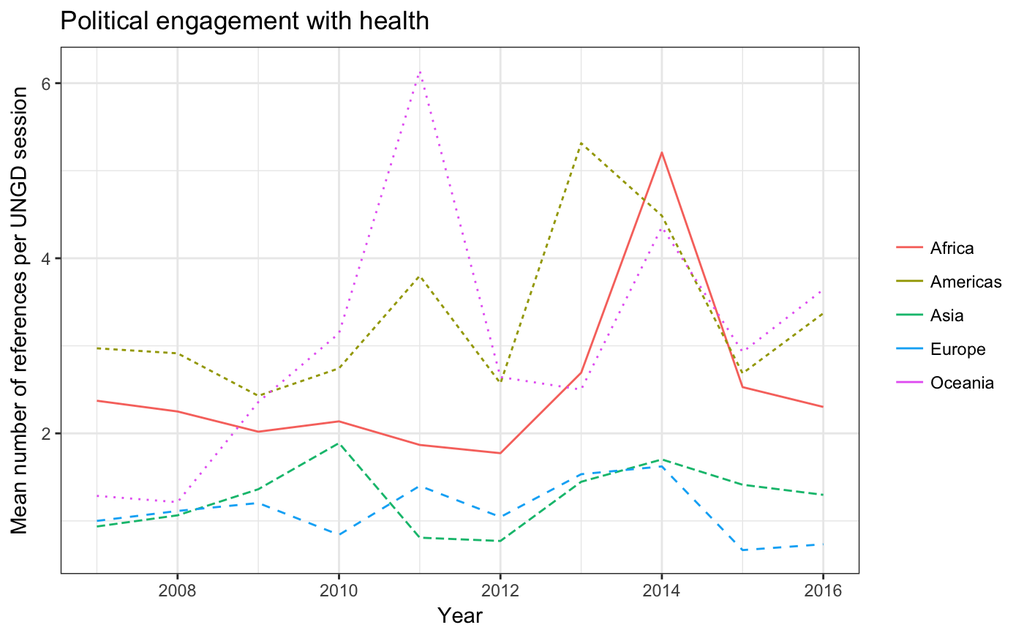

```r
ggplot(region_sum_tot, aes(x=V2, y=meanHEA, group=Region.Name,
                           colour = Region.Name, linetype = Region.Name)) +
  geom_line() +
  guides(colour=guide_legend(title=NULL), linetype = FALSE) +
  theme_bw() +
  ggtitle("Political engagement with health") +
  ylab("Mean number of references per UNGD session") + xlab("Year")
  ggsave("mean_health_by_region.pdf")
```

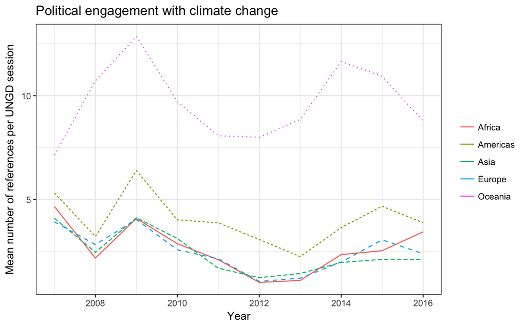

```r
ggplot(region_sum_tot, aes(x=V2, y=meanCC, group=Region.Name,
                           colour = Region.Name, linetype = Region.Name)) +
  geom_line() +
  guides(colour=guide_legend(title=NULL), linetype = FALSE) +
  theme_bw() +
  ggtitle("Political engagement with climate change") +
  ylab("Mean number of references per UNGD session") + xlab("Year")
  ggsave("mean_climate_by_region.pdf")
```

# Alternative way to deal with dictionary that doesn’t seem to work (right now).

```r
tok.c <- tokens_compound(tok.r, mydict, valuetype = "regex", concatenator = "_")
```

```r
tok.new2 <- tokens_select(tok.c, mydict, selection = "keep",
                         valuetype = "fixed",
                         padding = TRUE)
```

```r
dfm.new2 <- dfm(tok.new2)
View(dfm.new2)
```

```r
tok.hea2 <- kwic(tok.c, c("malaria", "diarrhoea", "infection", "disease", "sars", "measles", "pneumonia", "epidemic", "pandemic", "public health", "health care", "epidemiology", "healthcare", "health", "mortality", "morbidity", "nutrition", "illness", "infectious", "ncd", "non-communicable disease", "noncommunicable disease", "communicable disease", "air pollution", "nutrition", "malnutrition", "mental disorder", "stunting"), window = 100, valuetype = "regex")
```

```r
tok.cc2 <- kwic(tok.c, c("climate change", "global warming", "green house", "temperature", "extreme weather", "global environmental change", "climate variability", "greenhouse", "low carbon", "ghge", "renewable energy", "carbon emission", "co2 emission", "climate pollutant"), window = 50, valuetype = "regex")
```

```r
tok.x2 <- kwic(as.tokens(tok.hea), c("climate change", "global warming", "green house", "temperature", "extreme weather", "global environmental change", "climate variability", "greenhouse", "low carbon", "ghge", "renewable energy", "carbon emission", "co2 emission", "climate pollutant"), window = 50, valuetype = "regex")
```